# Machine Learning Project

DBW

## Background

Using devices such as Jawbone Up, Nike FuelBand, and Fitbit it is now possible to collect a large amount of data about personal activity relatively inexpensively. These type of devices are part of the quantified self movement – a group of enthusiasts who take measurements about themselves regularly to improve their health, to find patterns in their behavior, or because they are tech geeks. One thing that people regularly do is quantify how much of a particular activity they do, but they rarely quantify how well they do it. In this project, your goal will be to use data from accelerometers on the belt, forearm, arm, and dumbell of 6 participants. They were asked to perform barbell lifts correctly and incorrectly in 5 different ways. More information is available from the website here: http://groupware.les.inf.puc-rio.br/har (see the section on the Weight Lifting Exercise Dataset).

## Data

The training data for this project are available here:

https://d396qusza40orc.cloudfront.net/predmachlearn/pml-training.csv

The test data are available here:

https://d396qusza40orc.cloudfront.net/predmachlearn/pml-testing.csv

The data for this project come from this source: http://groupware.les.inf.puc-rio.br/har. If you use the document you create for this class for any purpose please cite them as they have been very generous in allowing their data to be used for this kind of assignment.

## Data Processing

First we loaded the data and then we removed all the entries that were not numeric and all the entries in which the whole column was composed of NAs. We then checked that the testing and training data had the same number of columns (variables).

```r
library(caret)
library(kernlab)
library(mlbench)
library(gridExtra)
library(dplyr)
#setingwd
setwd("~/Documents/repos/MachineLearning")
#loading the data
trainingRaw<-read.csv("~/Documents/repos/MachineLearning/pml-training.csv", na.strings = c("#DIV/0!","",NA), sep=",")
testingRaw<-read.csv("~/Documents/repos/MachineLearning/pml-testing.csv", na.strings = c("#DIV/0!","",NA), sep=",")
unique(trainingRaw$classe)
```

```
## [1] A B C D E
## Levels: A B C D E
```

```r
#cleaning the data (removing the X variable)
training<-trainingRaw[,-1]
testing<-testingRaw[,-1]

#staying only with numeric variables
training<-training[,sapply(training, is.numeric)]
testing<-testing[,sapply(testing, is.numeric)]

#removing NA
#all the columns which the sum is 0, has no NA
removeNA=apply(apply(training, FUN=is.na, 2), FUN=sum, 2)
training<-training[,removeNA==0]
training$classe<-trainingRaw$classe
dim(training)
```

```
## [1] 19622    56
```

```r
removeNA=apply(apply(testing, FUN=is.na, 2), FUN=sum, 2)
testing<-testing[,removeNA==0]
dim(testing)
```

```
## [1] 20 56
```

## Slicing the Data

We then cut our training data in two slices with 0.6 of observations in the Training Set and 0.4 in the Testing Set.

```r
#creating training and testing data
set.seed(123)
inTrain = createDataPartition(training$classe, p= 0.6, list=FALSE)
cross_training=training[inTrain,]
cross_testing=training[-inTrain,]
```

## Selecting the model

Since we will use a five categories classification the best option to use will be a tree model. Tree models suffer less from data variation, outliers and distribution and are very easy to interpret. We will know try to choose which is the best Tree Model and do a benchmark with a non-tree model (SVM). We will choose the best accuracy model to our predictions.

To achieve that we will run each model with a **5 fold cross-validation, 3 times,** to get the best accuracy estimate. The models we chose were:

**Bagging Tree**  
**Boosting Tree**  
**Random Forest**

**SVM**

```r
control <- trainControl(method="repeatedcv", repeats=3, number=5)
```

```r
#Bagging
set.seed(123)
Bagging<- train(classe~., data=cross_training, method="treebag",trControl=control, verbose=FALSE)
Bagging
```

```
## Bagged CART
##
## 11776 samples
##    55 predictor
##     5 classes: 'A', 'B', 'C', 'D', 'E'
##
## No pre-processing
## Resampling: Cross-Validated (5 fold, repeated 3 times)
## Summary of sample sizes: 9421, 9420, 9422, 9421, 9420, 9422, ...
## Resampling results
##
##   Accuracy   Kappa      Accuracy SD  Kappa SD
##   0.9966879  0.9958105  0.001246294  0.001576505
```

```r
#boosted Trees
set.seed(123)
Boosted <- train(classe~., data=cross_training, method="gbm", trControl=control, verbose=FALSE)
Boosted
```

```
## Stochastic Gradient Boosting
##
## 11776 samples
##    55 predictor
##     5 classes: 'A', 'B', 'C', 'D', 'E'
##
## No pre-processing
## Resampling: Cross-Validated (5 fold, repeated 3 times)
## Summary of sample sizes: 9421, 9420, 9422, 9420, 9421, 9422, ...
## Resampling results across tuning parameters:
##
##   interaction.depth  n.trees  Accuracy   Kappa      Accuracy SD
##   1                   50      0.8068394  0.7551519  0.011538756
##   1                  100      0.8833791  0.8523508  0.007603672
##   1                  150      0.9148840  0.8922442  0.008178442
##   2                   50      0.9324608  0.9144855  0.005559914
##   2                  100      0.9759682  0.9695942  0.004413336
##   2                  150      0.9894699  0.9866806  0.002908352
##   3                   50      0.9678726  0.9593472  0.004863664
##   3                  100      0.9908571  0.9884356  0.002527041
##   3                  150      0.9947067  0.9933045  0.001863915
##   Kappa SD
##   0.014616135
##   0.009660676
##   0.010385095
##   0.007054444
##   0.005588108
##   0.003678006
##   0.006159050
##   0.003196205
##   0.002357495
##
## Tuning parameter 'shrinkage' was held constant at a value of 0.1
##
## Tuning parameter 'n.minobsinnode' was held constant at a value of 10
## Accuracy was used to select the optimal model using  the largest value.
## The final values used for the model were n.trees = 150,
##  interaction.depth = 3, shrinkage = 0.1 and n.minobsinnode = 10.
```

```r
#Random Forest
set.seed(123)
RandFor<- train(classe~., data=cross_training, method="rf", trControl=control, verbose=FALSE)
RandFor
```

```
## Random Forest
##
## 11776 samples
##    55 predictor
##     5 classes: 'A', 'B', 'C', 'D', 'E'
##
## No pre-processing
## Resampling: Cross-Validated (5 fold, repeated 3 times)
## Summary of sample sizes: 9421, 9420, 9422, 9420, 9421, 9422, ...
## Resampling results across tuning parameters:
##
##   mtry  Accuracy   Kappa      Accuracy SD  Kappa SD
##    2    0.9941690  0.9926237  0.001790140  0.002264762
##   28    0.9976223  0.9969926  0.001261449  0.001595466
##   55    0.9970279  0.9962405  0.001613330  0.002041105
##
## Accuracy was used to select the optimal model using  the largest value.
## The final value used for the model was mtry = 28.
```

```r
#Just to be sure, lets check non-tree method accuracy
set.seed(123)
SVM<-train(classe~., data=cross_training, method="svmRadial", trControl=control, verbose=FALSE)
SVM
```

```
## Support Vector Machines with Radial Basis Function Kernel
##
## 11776 samples
##    55 predictor
##     5 classes: 'A', 'B', 'C', 'D', 'E'
##
## No pre-processing
## Resampling: Cross-Validated (5 fold, repeated 3 times)
## Summary of sample sizes: 9421, 9420, 9422, 9420, 9421, 9422, ...
## Resampling results across tuning parameters:
##
##   C     Accuracy   Kappa      Accuracy SD  Kappa SD
##   0.25  0.8503451  0.8108635  0.009451478  0.011887696
##   0.50  0.8849356  0.8543913  0.008490738  0.010712750
##   1.00  0.9138362  0.8908913  0.007869414  0.009987623
##
## Tuning parameter 'sigma' was held constant at a value of 0.01300142
## Accuracy was used to select the optimal model using  the largest value.
## The final values used for the model were sigma = 0.01300142 and C = 1.
```

#### Table and Figure comparing models

```r
#comparing methods
results<-resamples(list(Bagging = Bagging, Boosted = Boosted, RandFor = RandFor, SVM = SVM))
```

```r
summary(results)
```

```
##
## Call:
## summary.resamples(object = results)
##
## Models: Bagging, Boosted, RandFor, SVM
## Number of resamples: 15
##
## Accuracy
##           Min. 1st Qu. Median   Mean 3rd Qu.   Max. NA's
## Bagging 0.9928  0.9966 0.9970 0.9967  0.9972 0.9979    0
## Boosted 0.9902  0.9947 0.9949 0.9947  0.9958 0.9970    0
## RandFor 0.9949  0.9970 0.9979 0.9976  0.9985 0.9992    0
## SVM     0.9011  0.9079 0.9121 0.9138  0.9172 0.9300    0
##
## Kappa
##           Min. 1st Qu. Median   Mean 3rd Qu.   Max. NA's
## Bagging 0.9909  0.9957 0.9962 0.9958  0.9965 0.9973    0
## Boosted 0.9876  0.9933 0.9936 0.9933  0.9946 0.9962    0
## RandFor 0.9936  0.9962 0.9973 0.9970  0.9981 0.9989    0
## SVM     0.8746  0.8833 0.8887 0.8909  0.8952 0.9113    0
```

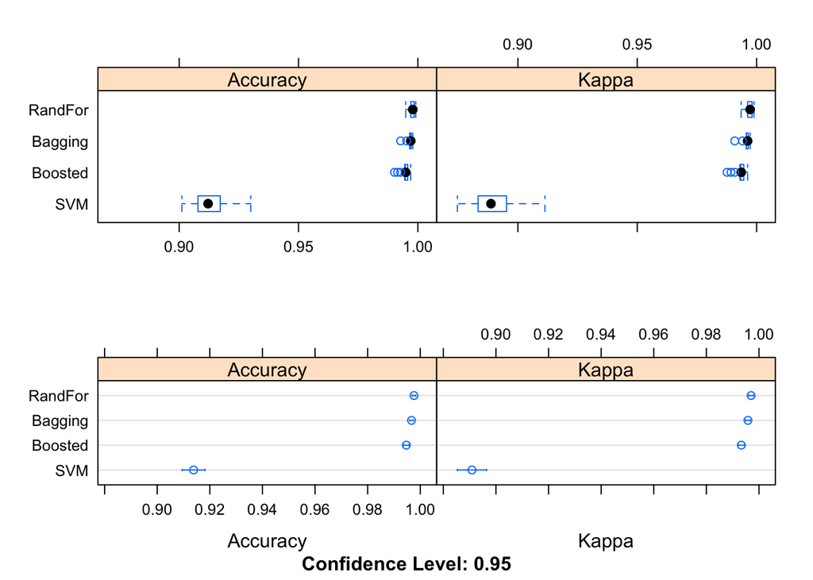

```r
g1<-bwplot(results)
g2<-dotplot(results)
grid.arrange(g1,g2,ncol=1)
```

## Testing the Model: Random Forest

Know, we should test it in our sliced testing dataset.

```r
#testing the best model
prediction<-predict(RandFor, cross_testing)
CMatrix<-confusionMatrix(prediction, cross_testing$classe)
CMatrix
```

```
## Confusion Matrix and Statistics
##
##           Reference
## Prediction    A    B    C    D    E
##          A 2232    0    0    0    0
##          B    0 1517    3    0    0
##          C    0    1 1362    0    0
##          D    0    0    3 1286    0
##          E    0    0    0    0 1442
##
## Overall Statistics
##
##                Accuracy : 0.9991
##                  95% CI : (0.9982, 0.9996)
##     No Information Rate : 0.2845
##     P-Value [Acc > NIR] : < 2.2e-16
##
##                   Kappa : 0.9989
##  Mcnemar's Test P-Value : NA
##
## Statistics by Class:
##
##                      Class: A Class: B Class: C Class: D Class: E
## Sensitivity            1.0000   0.9993   0.9956   1.0000   1.0000
## Specificity            1.0000   0.9995   0.9998   0.9995   1.0000
## Pos Pred Value         1.0000   0.9980   0.9993   0.9977   1.0000
## Neg Pred Value         1.0000   0.9998   0.9991   1.0000   1.0000
## Prevalence             0.2845   0.1935   0.1744   0.1639   0.1838
## Detection Rate         0.2845   0.1933   0.1736   0.1639   0.1838
## Detection Prevalence   0.2845   0.1937   0.1737   0.1643   0.1838
## Balanced Accuracy      1.0000   0.9994   0.9977   0.9998   1.0000
```

We could see that we got a **99.91% out-of-sample accuracy** with the Random Forest Model, meaning a **0.09% out-of-sample error.**

## Appendix: Figures

```r
knitr::kable(CMatrix$table)
```

|  | A | B | C | D | E |
| --- | --- | --- | --- | --- | --- |
| A | 2232 | 0 | 0 | 0 | 0 |
| B | 0 | 1517 | 3 | 0 | 0 |
| C | 0 | 1 | 1362 | 0 | 0 |
| D | 0 | 0 | 3 | 1286 | 0 |
| E | 0 | 0 | 0 | 0 | 1442 |

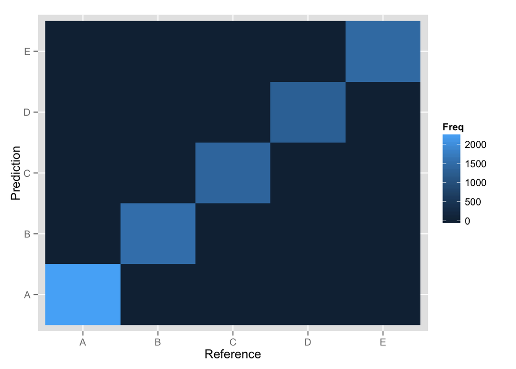

```r
C.data.frame<-as.data.frame(CMatrix$table)
g3<-ggplot(C.data.frame)+geom_tile(aes(x=Reference,y=Prediction,fill=Freq))
g3
```

## submit testing data

```r
finalresult<-as.character(predict(RandFor,testing))
finalresult
```

```
##  [1] "B" "A" "B" "A" "A" "E" "D" "B" "A" "A" "B" "C" "B" "A" "E" "E" "A"
## [18] "B" "B" "B"
```

```r
pml_write_files = function(x){
  n = length(x)
  for(i in 1:n){
    filename = paste0("problem_id_",i,".txt")
    write.table(x[i],file=filename,quote=FALSE,row.names=FALSE,col.names=FALSE)
  }
}
pml_write_files(finalresult)
```